# IMPACT OF MANUFACTURING YEAR AND MILEAGE ON USED CAR PRICES: A DATA-DRIVEN STUDY

```python
import pandas as pd
```

```python
df=pd.read_csv(r"cars24data.csv")
```

## How does the manufacturing year correlate with the resale price of Maruti vehicles?

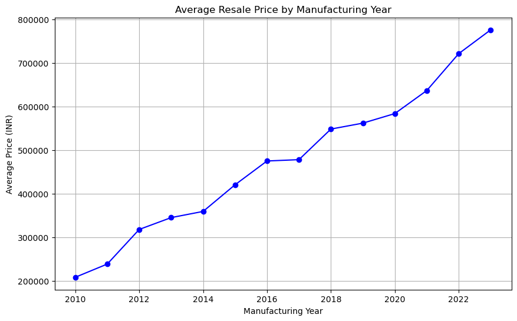

```python
import pandas as pd
import matplotlib.pyplot as plt

# Load data
df = pd.read_csv(r'cars24data.csv')

# Group by manufacturing year and calculate mean price
year_price = df.groupby('Manufacturing_year')['Price'].mean().reset_index()

# Plot
plt.figure(figsize=(10, 6))
plt.plot(year_price['Manufacturing_year'], year_price['Price'], marker='o', linestyle='-', color='blue')
plt.title('Average Resale Price by Manufacturing Year')
plt.xlabel('Manufacturing Year')
plt.ylabel('Average Price (INR)')
plt.grid(True)
plt.savefig("Average Resale Price by Manufacturing Year.png")
plt.show()
```

## What is the relationship between kilometers driven (KM Driven) and the listed price of used cars?

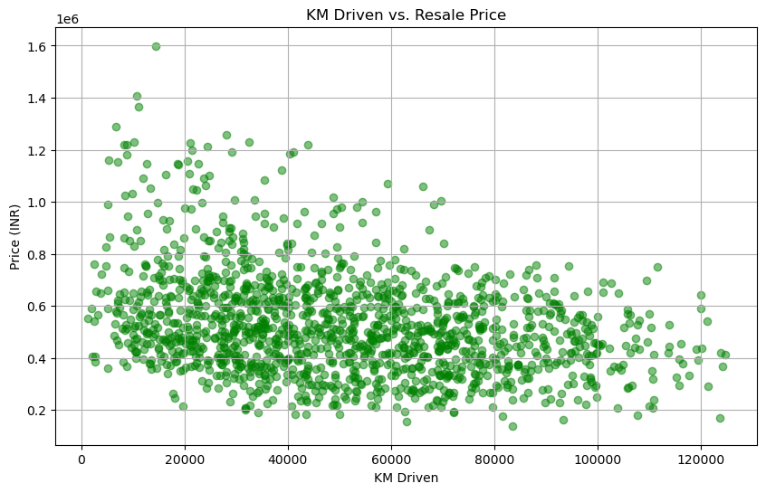

```python
plt.figure(figsize=(10, 6))
plt.scatter(df['KM driven'], df['Price'], alpha=0.5, color='green')
plt.title('KM Driven vs. Resale Price')
plt.xlabel('KM Driven')
plt.ylabel('Price (INR)')
plt.grid(True)
plt.savefig("KM Driven vs. Resale Price.png")
plt.show()
```

## Do automatic transmission vehicles command a price premium compared to manual transmission

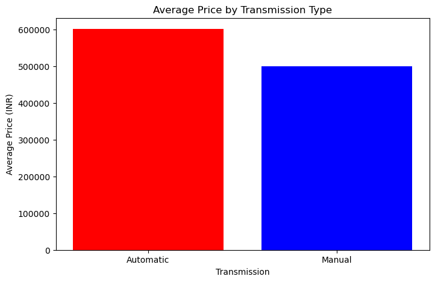

```python
transmission_price = df.groupby('Transmission')['Price'].mean().reset_index()

plt.figure(figsize=(8, 5))
plt.bar(transmission_price['Transmission'], transmission_price['Price'], color=['red', 'blue'])
plt.title('Average Price by Transmission Type')
plt.xlabel('Transmission')
plt.ylabel('Average Price (INR)')
plt.savefig("Average Price by Transmission Type.png")
plt.show()
```

## How does the number of previous owners (Ownership) influence the resale value of a vehicle?

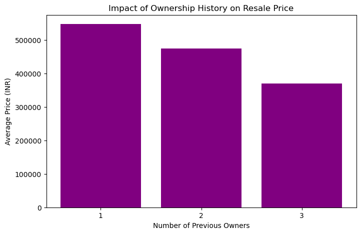

```python
ownership_price = df.groupby('Ownership')['Price'].mean().reset_index()

plt.figure(figsize=(8, 5))
plt.bar(ownership_price['Ownership'].astype(str), ownership_price['Price'], color='purple')
plt.title('Impact of Ownership History on Resale Price')
plt.xlabel('Number of Previous Owners')
plt.ylabel('Average Price (INR)')
plt.savefig("Impact of Ownership History on Resale Price.png")
plt.show()
```

## Are diesel-powered vehicles priced differently from petrol or CNG variants in comparable models?

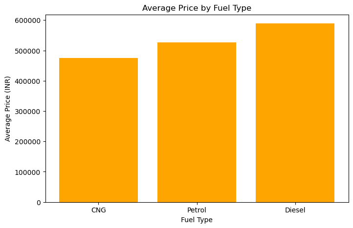

```python
fuel_price = df.groupby('Fuel type')['Price'].mean().sort_values().reset_index()

plt.figure(figsize=(8, 5))
plt.bar(fuel_price['Fuel type'], fuel_price['Price'], color='orange')
plt.title('Average Price by Fuel Type')
plt.xlabel('Fuel Type')
plt.ylabel('Average Price (INR)')
plt.savefig("Average Price by Fuel Type.png")
plt.show()
```

## Do vehicles with a spare key (Yes/No) sell at a higher price than those without?

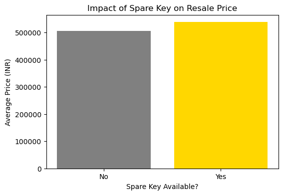

```python
spare_key_price = df.groupby('Spare key')['Price'].mean().reset_index()

plt.figure(figsize=(6, 4))
plt.bar(spare_key_price['Spare key'], spare_key_price['Price'], color=['gray', 'gold'])
plt.title('Impact of Spare Key on Resale Price')
plt.xlabel('Spare Key Available?')
plt.ylabel('Average Price (INR)')
plt.savefig("Impact of Spare Key on Resale Price.png")
plt.show()
```

## Which Maruti models retain their value best over time, and why?

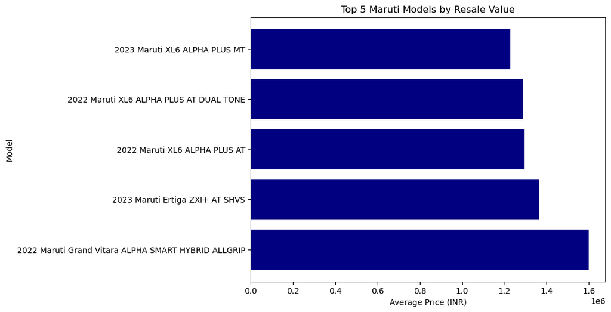

```python
model_price = df.groupby('Model Name')['Price'].mean().nlargest(5).reset_index()

plt.figure(figsize=(8, 6))
plt.barh(model_price['Model Name'], model_price['Price'], color='navy')
plt.title('Top 5 Maruti Models by Resale Value')
plt.xlabel('Average Price (INR)')
plt.ylabel('Model')
plt.show()
```

## How do repainted parts (count) influence buyer decisions and pricing?

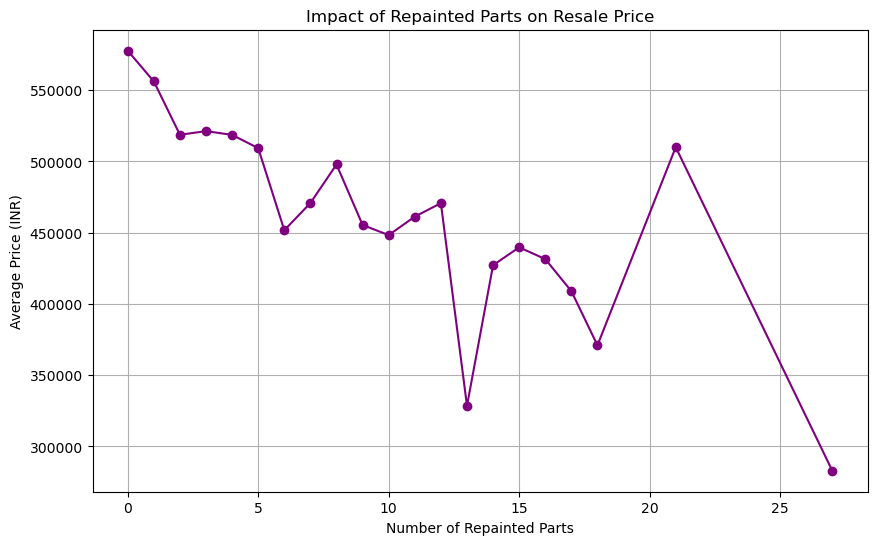

```python
repainted_price = df.groupby('Repainted Parts')['Price'].mean().reset_index()

plt.figure(figsize=(10, 6))
plt.plot(repainted_price['Repainted Parts'], repainted_price['Price'], marker='o', color='purple')
plt.title('Impact of Repainted Parts on Resale Price')
plt.xlabel('Number of Repainted Parts')
plt.ylabel('Average Price (INR)')
plt.grid(True)
plt.savefig("Impact of Repainted Parts on Resale Price.png")
plt.show()
```

## What is the average depreciation rate for Maruti vehicles based on age and mileage?

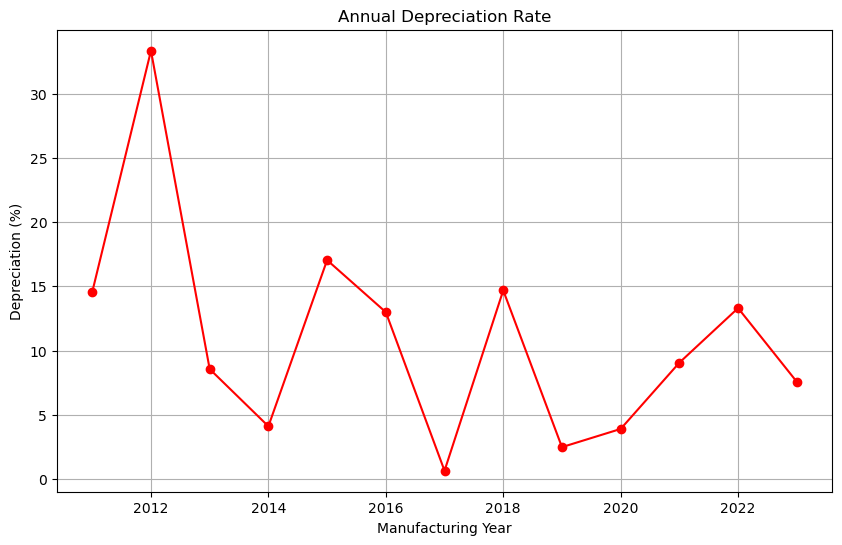

```python
# Calculate year-over-year depreciation
year_price['Depreciation (%)'] = year_price['Price'].pct_change() * 100

plt.figure(figsize=(10, 6))
plt.plot(year_price['Manufacturing_year'], year_price['Depreciation (%)'], marker='o', color='red')
plt.title('Annual Depreciation Rate')
plt.xlabel('Manufacturing Year')
plt.ylabel('Depreciation (%)')
plt.grid(True)
plt.savefig("Annual Depreciation Rate.png")
plt.show()
```

## Are newer models (e.g., 2022–2023) more likely to have fewer imperfections than older models?

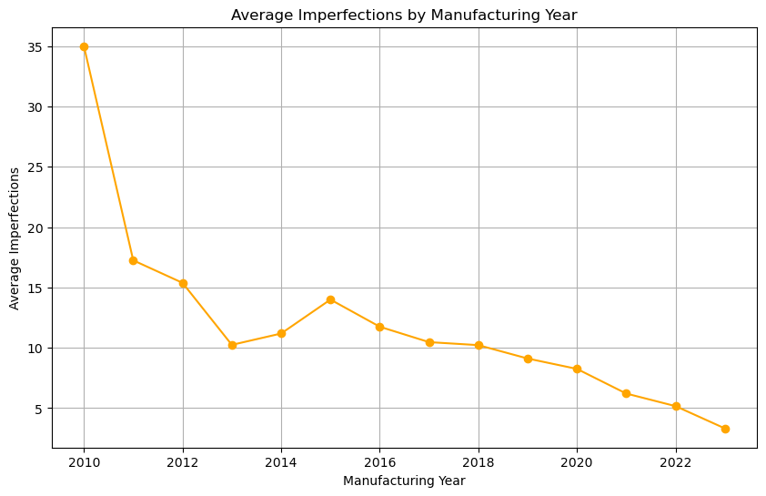

```python
year_imperfections = df.groupby('Manufacturing_year')['Imperfections'].mean().reset_index()

plt.figure(figsize=(10, 6))
plt.plot(year_imperfections['Manufacturing_year'], year_imperfections['Imperfections'], marker='o', color='orange')
plt.title('Average Imperfections by Manufacturing Year')
plt.xlabel('Manufacturing Year')
plt.ylabel('Average Imperfections')
plt.grid(True)
plt.savefig("Average Imperfections by Manufacturing Year.png")
plt.show()
```

## Do vehicles with hybrid or SHVS (Smart Hybrid Vehicle) technology have higher resale values?

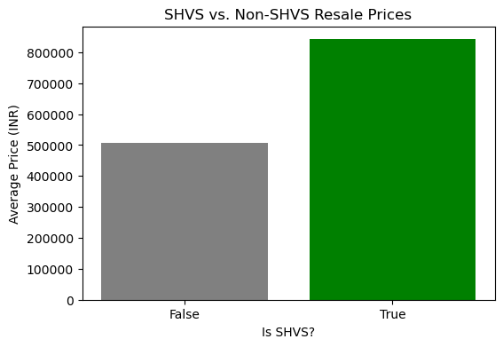

```python
# Identify SHVS models
df['Is_SHVS'] = df['Model Name'].str.contains('SHVS')
shvs_price = df.groupby('Is_SHVS')['Price'].mean().reset_index()

plt.figure(figsize=(6, 4))
plt.bar(shvs_price['Is_SHVS'].astype(str), shvs_price['Price'], color=['gray', 'green'])
plt.title('SHVS vs. Non-SHVS Resale Prices')
plt.xlabel('Is SHVS?')
plt.ylabel('Average Price (INR)')
plt.savefig("SHVS vs. Non-SHVS Resale Prices.png")
plt.show()
```

## How does ownership history interact with fuel type to influence resale prices?

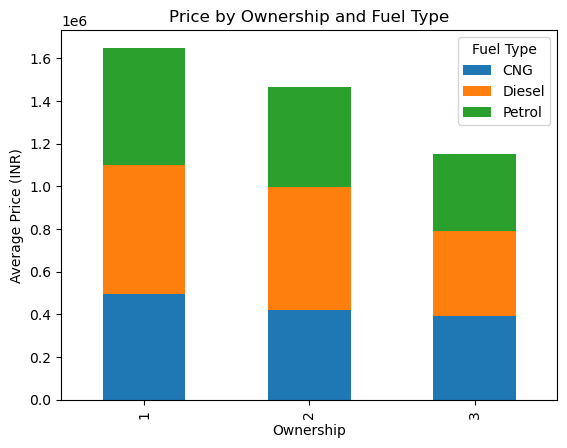

```python
ownership_fuel = pd.crosstab(df['Ownership'], df['Fuel type'], values=df['Price'], aggfunc='mean')

plt.figure(figsize=(10, 6))
ownership_fuel.plot(kind='bar', stacked=True)
plt.title('Price by Ownership and Fuel Type')
plt.xlabel('Ownership')
plt.ylabel('Average Price (INR)')
plt.legend(title='Fuel Type')
plt.savefig("Price by Ownership and Fuel Type.png")
plt.show()
```

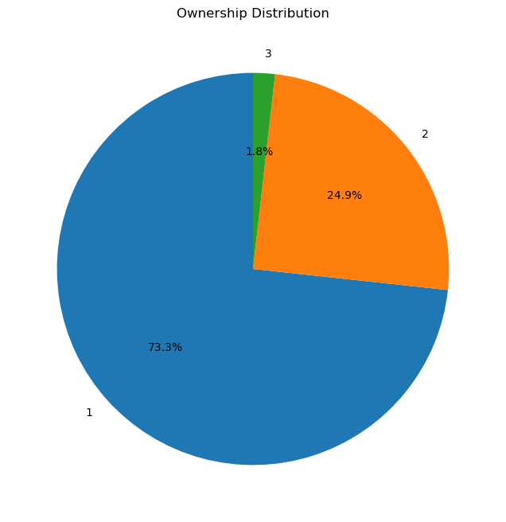

```python
ownership_dist = df['Ownership'].value_counts()

plt.figure(figsize=(8, 8))
plt.pie(ownership_dist, labels=ownership_dist.index, autopct='%1.1f%%', startangle=90)
plt.title('Ownership Distribution')
plt.savefig("Ownership Distribution.png")
plt.show()
```

## Is there a significant correlation between the number of imperfections and the final resale price?

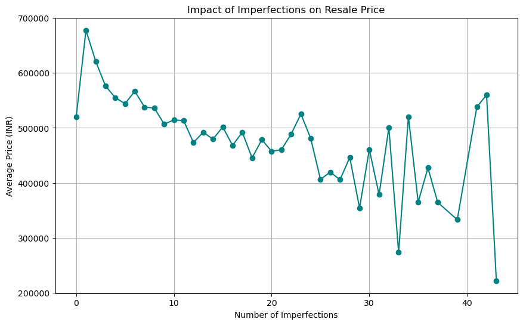

```python
imperfections_price = df.groupby('Imperfections')['Price'].mean().reset_index()

plt.figure(figsize=(10, 6))
plt.plot(imperfections_price['Imperfections'], imperfections_price['Price'], marker='o', color='teal')
plt.title('Impact of Imperfections on Resale Price')
plt.xlabel('Number of Imperfections')
plt.ylabel('Average Price (INR)')
plt.grid(True)
plt.savefig("Impact of Imperfections on Resale Price.png")
plt.show()
```